# SI 618: Data Manipulation and Analysis

## 05 - Data analysis: ANOVA, t-test, linear models

### Dr. Chris Teplovs, School of Information, University of Michigan

This work is licensed under a [Creative Commons Attribution-NonCommercial-ShareAlike 4.0 International License](http://creativecommons.org/licenses/by-nc-sa/4.0/).

## Overview

- questions/comments/concerns
  - pace/workload
- homework review
- distributions
- visualization theory
- t-tests
- regression
- ANOVA

## Why do we care about distributions?

## World is not normal

- Many other kinds of distributions
- We can tell what they are by looking at distribution

```python
import numpy as np
import pandas as pd
import matplotlib.pyplot as plt
import seaborn as sns
import scipy.stats as stats
%matplotlib inline
```

## Uniform

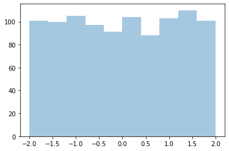

```python
uniform = np.random.uniform(-2,2,1000)  # low,high,count
sns.distplot(uniform,kde=False,norm_hist=False)
```

## Bimodal

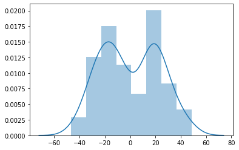

```python
bimodal = np.append(np.random.normal(-20,10,100), #Take a random distribution centered at two different locations, append them together, plot them
                    np.random.normal(20,10,100))
sns.distplot(bimodal,kde=True,norm_hist=True)
```

# Poisson

$$ P(k~events~in~interval) = \frac{\lambda^ke^{-\lambda}}{k!} $$

$\lambda$ is the event rate

Examples

- Meteor strikes
- Arrival of patients to hospital

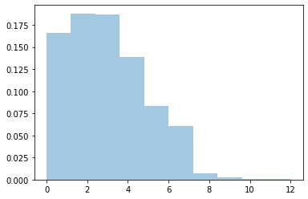

```python
# as lambda goes up --> looks more normal
pois = np.random.poisson(3,100000) # lambda, count
sns.distplot(pois,kde=False,bins=10,norm_hist=True) # Rare events with lots of zeroes, number of some events per time unit
```

# Power/Zipf/Pareto

$$ P = \frac{x^{-a}}{\zeta(a)}$$

"long tail"

- degree distribution
- movie/music popularity
- words

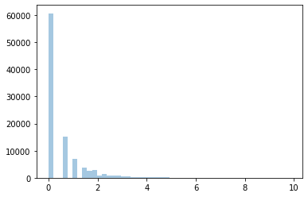

```python
power = np.random.zipf(2,100000)
sns.distplot(np.log(power),kde=False) #High frequency of certain somethings, ex: highest frequency words in english language
```

## Visual Tests on Data

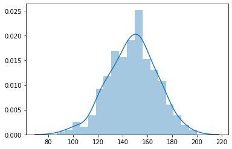

```python
testdata = (np.random.standard_normal(500)*20+150).astype(int)
sns.distplot(testdata)
```

## Run Sequence

- Run Sequence (index versus value)
- flat and non-drifting
  - fixed-location assumption holds
- vertical spread same over the entire plot,
  - then the fixed-variation assumption holds.

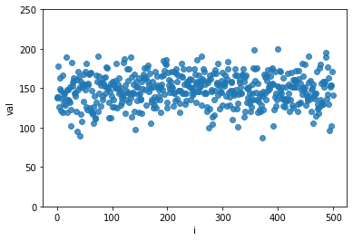

```python
ax = sns.regplot(np.arange(len(testdata)),testdata,fit_reg=False)
ax.set_ylim(0,250)
ax.set_ylabel("val")
ax.set_xlabel("i")
```

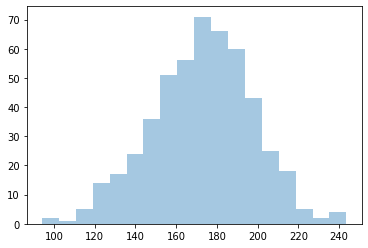

```python
drifting = np.array([testdata[i]+i*(.1) for i in np.arange(len(testdata))]) #Introduced a bias
sns.distplot(drifting,kde=False)
```

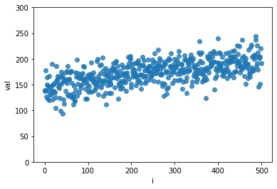

```python
ax = sns.regplot(np.arange(len(drifting)),drifting,fit_reg=False) # Value is not independent of the axis because the sequence trends upwards
ax.set_ylim(0,300)
ax.set_ylabel("val")
ax.set_xlabel("i")
```

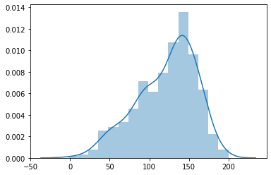

```python
expanding = np.array([(testdata[i]+i*np.random.randint(-1,1)*.2)
                     for i in np.arange(len(testdata))])
sns.distplot(expanding,kde=True,norm_hist=True)
```

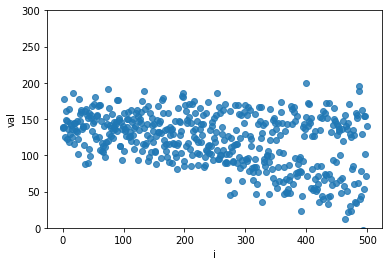

```python
ax = sns.regplot(np.arange(len(expanding)),expanding,fit_reg=False) #Not a normal distribution because it appears the observations are not independent of one another
ax.set_ylim(0,300)
ax.set_ylabel("val")
ax.set_xlabel("i")
```

# Lag Plot

- Plot point $y_i$ versus $y_{i-1}$
- If the lag plot is structureless
  - randomness assumption holds.

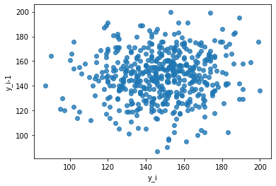

```python
lag = testdata.copy() # Plot each point versus the previous point
lag = np.array(lag[:-1])
current = testdata[1:]
ax = sns.regplot(current,lag,fit_reg=False)
ax.set_ylabel("y_i-1")
ax.set_xlabel("y_i")

#Should be round, should be more dense in the middle if a normal distribution
```

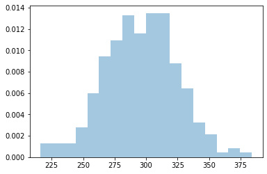

```python
connected = np.array([testdata[i]+testdata[i-1] for i in np.arange(500)])
sns.distplot(connected,kde=False,norm_hist=True)
```

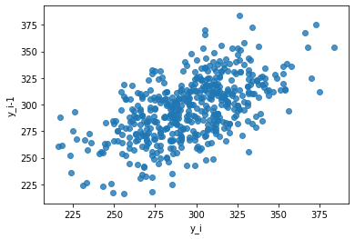

```python
lag = connected.copy()
lag = np.array(lag[:-1])
current = connected[1:]
ax = sns.regplot(current,lag,fit_reg=False)
ax.set_ylabel("y_i-1")
ax.set_xlabel("y_i")
```

## QQ Plot

- QQ Plots takes our n ordered data points
  - sorted from smallest to largest
- Asks:
  - What is the relationship between quantiles from our data and quantiles from a theoretical distribution that we're assuming the sample is drawn from

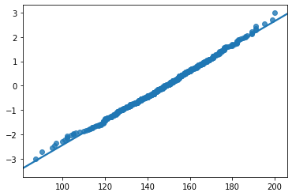

```python
qntls, xr = stats.probplot(testdata, fit=False)
sns.regplot(xr,qntls)

#Compares observed quantile of a distribution vs the predicted quantile
```

```python
def random_snorm(n, mean = 0, sd = 1, xi = 1.5):
    def random_snorm_aux(n, xi):
        weight = xi/(xi + 1/xi)
        z = np.random.uniform(-weight,1-weight,n)
        xi_ = xi**np.sign(z)
        random = -np.absolute(np.random.normal(0,1,n))/xi_ * np.sign(z)
        m1 = 2/np.sqrt(2 * np.pi)
        mu = m1 * (xi - 1/xi)
        sigma = np.sqrt((1 - m1**2) * (xi**2 + 1/xi**2) + 2 * m1**2 - 1)
        return (random - mu)/sigma

    return random_snorm_aux(n, xi) * sd + mean
```

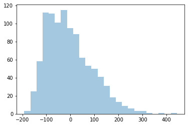

```python
rightskewed = random_snorm(1000,xi=2)*100
sns.distplot(rightskewed,kde=False)
```

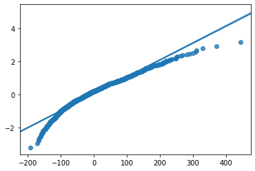

```python
qntls, xr = stats.probplot(rightskewed, fit=False)
sns.regplot(xr,qntls) #Falls off of the line to the right (skewed right)
```

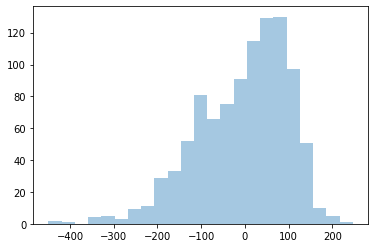

```python
leftskewed = random_snorm(1000,xi=-2)*100
sns.distplot(leftskewed,kde=False)
```

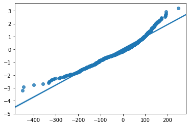

```python
qntls, xr = stats.probplot(leftskewed, fit=False)
sns.regplot(xr,qntls) #Skewed left as it curves upwards
#Departures from the regression say theres something wonky about the data
```

## Now the serious plots... let's wrap them in a single function that we can call

```python
def multiplePlots( series ):

    fig, axs = plt.subplots(2,2)
    plt.tight_layout(pad=0.4, w_pad=4, h_pad=1.0)

    # Histogram
    sns.distplot(series, ax=axs[0,0])

    # Lag plot
    lag = series.copy()
    lag = np.array(lag[:-1])
    current = series[1:]
    ax = sns.regplot(current,lag,fit_reg=False, ax=axs[0,1])
    ax.set_ylabel("y_i-1")
    ax.set_xlabel("y_i")

    # QQ plot
    qntls, xr = stats.probplot(series, fit=False)
    sns.regplot(xr,qntls, ax=axs[1,0])

    # Run sequence
    ax = sns.regplot(np.arange(len(series)),series, ax=axs[1,1])
    ax.set_ylabel("val")
    ax.set_xlabel("i")
```

### Group Question (Q0):

The sample.csv file, included with today's lab, contains 9 variables (v0 through v9) that contain measures drawn from different distributions. Your task is to use the investigative techniques we discussed in today's lab to determine what type of distribution the sample is drawn from.

You should first load the CSV file into a DataFrame, then look at various aspects of **each** variable.

**Your responses should consist of code cells, as well as markdown cells that state something like:**

> Variable v99 appears to be drawn from a uniform distribution with mean X and standard deviation Y.  
> A histogram of the data appears to be... The QQ plot shows....

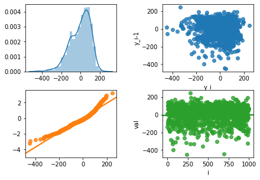

```python
multiplePlots(leftskewed)

sample = pd.read_csv('data/sample.csv')
```

```python
sample.describe()
sample["v5"].max()
sample["v5"].min()
```

```
0
```

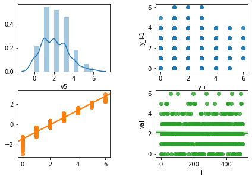

```python
multiplePlots(sample["v5"])
```

## Visualization for Data Scientists

We're going to ask a special virtual guest lecturer to provide some background on data visualization. Together, we'll watch [a brief (8-minute video) by Dr. Chris Brooks](https://www.coursera.org/learn/python-plotting/lecture/qrqqa/tools-for-thinking-about-design-alberto-cairo) and pause it several times to answer the following questions:

## Q1a: As someone who is studying data science, who are you trying to reach through your visualizations?

There are multiple layers of people that I am trying to reach through my visualizations. On one level, I need to be able to discuss the data on a deep level with my peers. However, this data must also be communicated with business professionals and in laymans terms. Eventually, the audience of the visualization will determine how complex the visualization must be.

## Q1b: What sense can you make of this image?

[figure not shown]

This image has a lot of complexity to it. At first glance, it was hard to determine much of anything. Even after studying it's hard to discern what's happening. The histograms combined with the scatter plot mix too much.

## Q1c: How many different kinds of information can you see in the Minard graphic, and what are they?

[figure not shown]

There are 5 different kinds of information represented. The distance traveled, the path taken, the geography represented by the black lines, the temperature, the size of the army via the width of the brown line.

## Returning to Seaborn:

https://seaborn.pydata.org/examples/index.html

Take a look at the different visualizations that are possible.